# Quiz 230524 (Birthday Problem, Matching Problem, Monty Hall Show)

coop711

2023-05-24

## Red, Black을 잘못 표시한 사람들

랜덤화출석부에 있는 Red, Black 과 실제 구글예습퀴즈에 올린 Red, Black 이 다른 사람들이 있어서 파악해 보았습니다. 랜덤화 효과를 논하기에는 아주 적은 인원이 관찰되었습니다. Red를 Black 이라고 한 사람이 4명, Black 을 Red 라고 한 사람이 1명 관찰되었습니다.

| 학번 | 랜덤화출석부 | 구글예습퀴즈 |
| --- | --- | --- |
| 20222421 | Red | Black |
| 20223518 | Red | Black |
| 20226646 | Red | Black |
| 20233832 | Red | Black |
| 20236148 | Black | Red |

|  | Red(구글예습퀴즈) | Black(구글예습퀴즈) |
| --- | --- | --- |
| **Red(랜덤화출석부)** | 437 | 4 |
| **Black(랜덤화출석부)** | 1 | 429 |

# 퀴즈 응답

## Birthday Problem

### 어느 날에 몇 명씩 생일이 같은가?

| **01월01일** | 3 |
| --- | --- |
| **01월02일** | 4 |
| **01월03일** | 4 |
| **01월04일** | 3 |
| **01월07일** | 2 |
| **01월10일** | 2 |
| **01월11일** | 2 |
| **01월13일** | 2 |
| **01월15일** | 3 |
| **01월17일** | 2 |
| **01월19일** | 4 |
| **01월20일** | 3 |
| **01월21일** | 2 |
| **01월22일** | 2 |
| **01월23일** | 6 |
| **01월24일** | 2 |
| **01월25일** | 2 |
| **01월26일** | 7 |
| **01월27일** | 3 |
| **01월29일** | 3 |
| **01월30일** | 5 |
| **01월31일** | 4 |
| **02월01일** | 4 |
| **02월03일** | 7 |
| **02월04일** | 5 |
| **02월05일** | 3 |
| **02월06일** | 3 |
| **02월08일** | 3 |
| **02월09일** | 4 |
| **02월10일** | 3 |
| **02월11일** | 2 |

[output cut: 222 more lines]

### 생일이 같은 사람은 몇 명 정도 기대되는가?

생일이 같은 날은 252 일 이다. $N$을 전체 인원이라 할 때, 기대 인원은 $N\times\{1- (\frac{364}{365})^{N-1}\}$, 분산은 $N\times\{1- (\frac{364}{365})^{N-1}\} + N\times(N-1)\times\{1-(\frac{363}{365})^{N-2}\}$로 계산된다.

무응답이거나 결석한 학생을 제외한 응답 인원 871명에 대하여 기대인원을 계산하면 790.9명, 표준오차는 28.1명으로 계산되어 관찰된 값이 그 범위에 잘 들어감을 알 수 있다.

#### 기대되는 인원

```
## [1] 790.9
```

#### 표준오차

```
## [1] 28.1
```

### 태어난 달의 분포는?

|  | 1월 | 2월 | 3월 | 4월 | 5월 | 6월 | 7월 | 8월 | 9월 | 10월 | 11월 | 12월 | 계 |
| --- | --- | --- | --- | --- | --- | --- | --- | --- | --- | --- | --- | --- | --- |
| Red | 37 | 40 | 40 | 43 | 40 | 31 | 30 | 29 | 40 | 38 | 46 | 24 | 438 |
| Black | 37 | 34 | 56 | 34 | 35 | 34 | 31 | 30 | 39 | 39 | 37 | 27 | 433 |
| 계 | 74 | 74 | 96 | 77 | 75 | 65 | 61 | 59 | 79 | 77 | 83 | 51 | 871 |

#### 랜덤화 효과

Pearson’s Chi-squared test: `.`

| Test statistic | df | P value |
| --- | --- | --- |
| 5.86 | 11 | 0.8826 |

#### 월별로 고르게 출생하였는가?

Chi-squared test for given probabilities: `.`

| Test statistic | df | P value |
| --- | --- | --- |
| 21.89 | 11 | 0.02523 * |

## Matching Problem

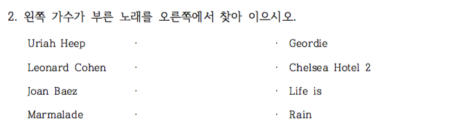

### 응답 분포

|  | Geordie | Chelsea Hotel II | Life is | Rain | 계 |
| --- | --- | --- | --- | --- | --- |
| **Urian Heep** | 281 | 286 | 192 | 112 | 871 |
| **Leonard Cohen** | 376 | 159 | 259 | 77 | 871 |
| **Joan Baez** | 142 | 197 | 319 | 213 | 871 |
| **Marmalade** | 72 | 229 | 101 | 469 | 871 |
| **계** | 871 | 871 | 871 | 871 | 3484 |

### 응답분포(가수별 %)

|  | Geordie | Chelsea Hotel II | Life is | Rain | 계 |
| --- | --- | --- | --- | --- | --- |
| **Urian Heep (Rain)** | 32.3 | 32.8 | 22 | 12.9 | 100 |
| **Leonard Cohen (Chelsea Hotel II)** | 43.2 | 18.3 | 29.7 | 8.8 | 100 |
| **Joan Baez (Geordie)** | 16.3 | 22.6 | 36.6 | 24.5 | 100 |
| **Marmalade (Life is)** | 8.3 | 26.3 | 11.6 | 53.8 | 100 |

### 정답갯수의 분포

|  | 0개 | 1개 | 2개 | 4개 | 계 |
| --- | --- | --- | --- | --- | --- |
| **Red** | 142 | 225 | 63 | 8 | 438 |
| **Black** | 145 | 203 | 70 | 15 | 433 |
| **계** | 287 | 428 | 133 | 23 | 871 |

### 랜덤화 효과

Pearson’s Chi-squared test: `.`

| Test statistic | df | P value |
| --- | --- | --- |
| 3.632 | 3 | 0.304 |

### Observed vs Expected

Observed vs Expected

|  | 0개 | 1개 | 2개 | 4개 | 계 |
| --- | --- | --- | --- | --- | --- |
| **Observed** | 287.0 | 428.0 | 133.0 | 23.0 | 871.0 |
| **Expected** | 326.6 | 290.3 | 217.8 | 36.3 | 871.0 |
| **Difference** | -39.6 | 137.7 | -84.8 | -13.3 | 0.0 |

### 매칭 모델 카이제곱 적합도 테스트

Chi-squared test for given probabilities: `.`

| Test statistic | df | P value |
| --- | --- | --- |
| 107.9 | 3 | 3.049e-23 * * * |

## 직관과 어긋나는 용어

### 연비

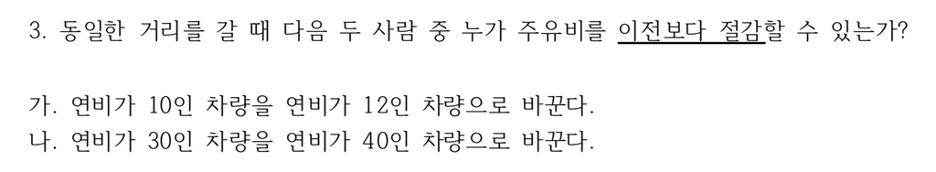

### 집계

|  | 연비 10 => 12 | 연비 30 => 40 | 계 |
| --- | --- | --- | --- |
| Red | 178 | 260 | 438 |
| Black | 176 | 257 | 433 |
| 계 | 354 | 517 | 871 |

Chi-squared test for given probabilities: `.`

| Test statistic | df | P value |
| --- | --- | --- |
| 0.0287 | 1 | 0.8655 |

### % 비교.

| 연비 10 => 12 | 연비 30 => 40 | 계 |
| --- | --- | --- |
| 40.6 | 59.4 | 100.0 |

# Monty Hall 문제

## 문항 배열 효과?

### Red

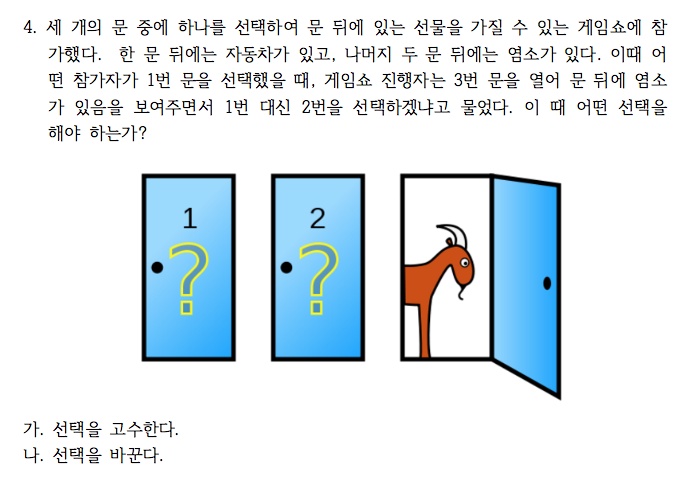

### Black

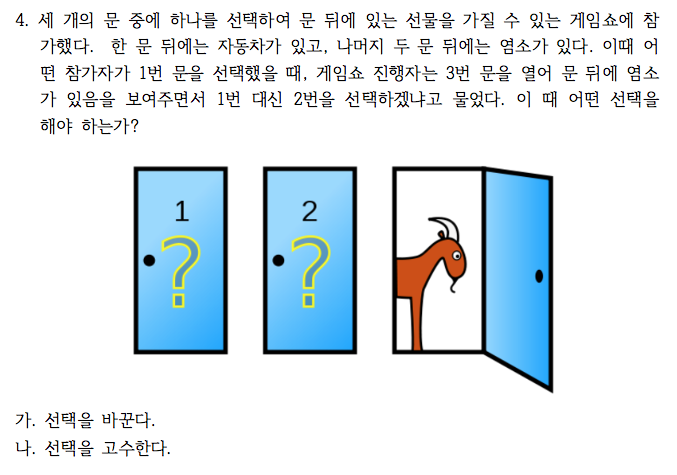

### 집계

|  | 고수한다 | 바꾼다 | 계 |
| --- | --- | --- | --- |
| **Red** | 309 | 129 | 438 |
| **Black** | 265 | 168 | 433 |
| **계** | 574 | 297 | 871 |

Pearson’s Chi-squared test with Yates’ continuity correction: `.`

| Test statistic | df | P value |
| --- | --- | --- |
| 8.055 | 1 | 0.004538 * * |

### % 비교.

|  | 고수한다 | 바꾼다 | 계 |
| --- | --- | --- | --- |
| **Red** | 70.5 | 29.5 | 100.0 |
| **Black** | 61.2 | 38.8 | 100.0 |

### 합산(%)

|  | 고수한다 | 바꾼다 | 계 |
| --- | --- | --- | --- |
| **계** | 65.9 | 34.1 | 100.0 |

### Mosaic Plot

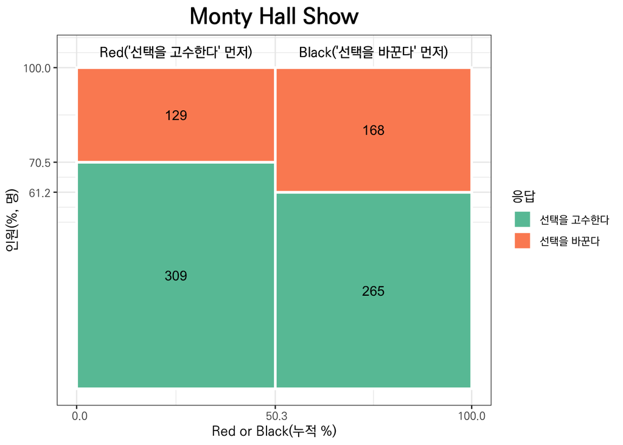

## 일 단위 마감 시간으로부터 제출 시간의 분포

일 단위

|  | [0,1] | (1,2] | (2,3] | (3,4] | (4,5] | (5,6] | (6,7] | (7,8] | (8,9] | (9,10] | (10,11] | (11,12] | (12,13] | (13,14] |
| --- | --- | --- | --- | --- | --- | --- | --- | --- | --- | --- | --- | --- | --- | --- |
| **Red** | 189 | 34 | 36 | 19 | 13 | 7 | 15 | 24 | 18 | 11 | 7 | 11 | 18 | 34 |
| **Black** | 174 | 39 | 22 | 16 | 9 | 7 | 12 | 33 | 20 | 28 | 6 | 17 | 14 | 35 |

Pearson’s Chi-squared test: `.`

| Test statistic | df | P value |
| --- | --- | --- |
| 16.45 | 13 | 0.2254 |

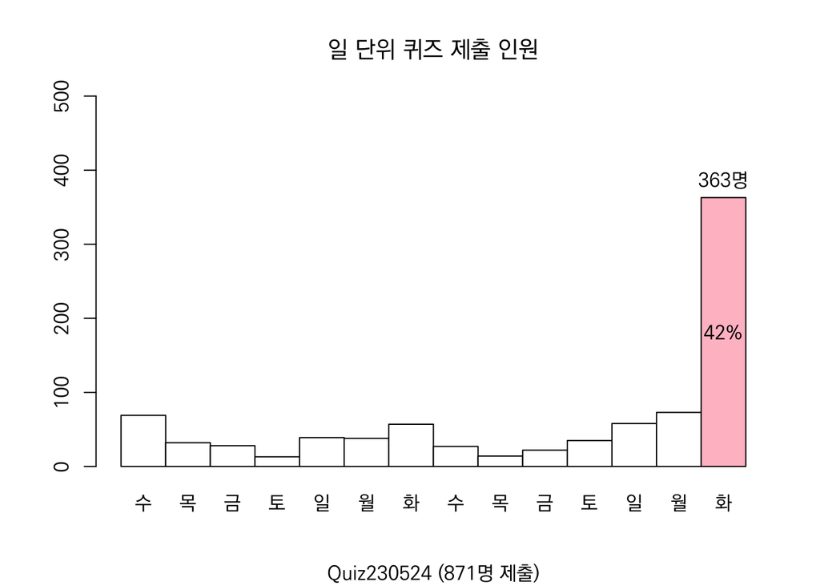

## 제출 시간 분포의 변화

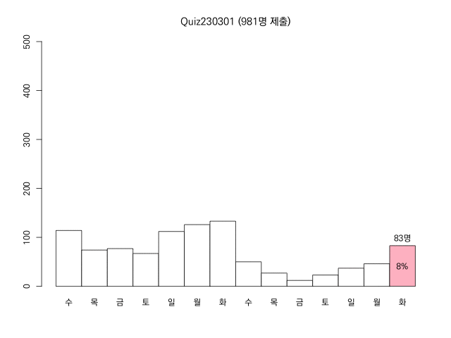